# 5. ggplot2（棒グラフ）

Masahiko Asano

2026-06-03

- **このセクションで使っている `R packages`**

```r
library(DT)
library(gapminder)
library(gghighlight)
library(ggrepel)
library(stargazer)
library(tidyverse)
```

# 1. 棒グラフとは

- 棒グラフ (`bar chart`) は離散変数の分布を示す方法の一つ

| 変数 | 可視化の方法 | 特徴 |
| --- | --- | --- |
| 離散変数 | **棒グラフ** | 棒の間の線あり |

#### ヒストグラムと棒グラフの違い

- ヒストグラムは連続変数（=間隔尺度と比率尺度）の分布を確認する普遍的な可視化方法
- ヒストグラムの見た目は棒グラフと非常に似ている

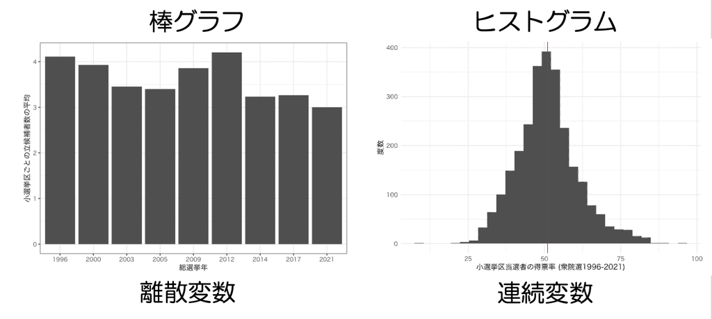

- 両者の違い：  
  ・棒グラフは「離散変数」、ヒストグラムは「連続変数」を可視化する  
  ・棒と棒の間の隙間の有無

| 変数 | 可視化の方法 | 特徴 |
| --- | --- | --- |
| 離散変数 | **棒グラフ** | 棒の間の線あり |
| 連続変数 | **ヒストグラム** | 棒の間の線なし |

##### 横軸が「総選挙での得票率」のヒストグラムの場合

- 1%, 1.1%, …. 〜100%まで、無数の値が存在する
- 棒を並べるとしたら隙間なく棒を並べる必要がある  
  → 値ごとに棒は立てない  
  → しかし、それぞれの棒には「棒の横軸上の位置と高さ」という情報が含まれている

# 2. データの準備

衆院選データ (`hr96-26.csv`)の準備  
・hr96-26.csv をクリックしてデータをパソコンにダウンロード  
・選挙データの読み取り

```r
df <- read_csv("data/hr96-26.csv",
               na = ".")
```

## 読み取った選挙データを確認

- `hr96_17.csv` は1996年に衆院選挙に小選挙区が導入されて以来実施された 11 回の衆議院選挙（1996, 2000, 2003, 2005, 2009, 2012, 2014, 2017, 2021, 2024, 2026）の結果のデータ
- `df` に含まれる変数名を表示させる

```r
names(df)
```

```
 [1] "year"          "pref"          "ku"            "kun"
 [5] "rank"          "wl"            "nocand"        "seito"
 [9] "j_name"        "name"          "previous"      "gender"
[13] "age"           "exp"           "status"        "vote"
[17] "voteshare"     "eligible"      "turnout"       "seshu_dummy"
[21] "jiban_seshu"   "nojiban_seshu"
```

- `df` には 22 個の変数が入っている

| 変数名 | 詳細 |
| --- | --- |
| 1. year | 選挙年 (1996-2026) |
| 2. pref | 都道府県名 |
| 3. ku | 小選挙区名 |
| 4. kun | 小選挙区 |
| 5. wl | 選挙の当落: 1 = 小選挙区当選、2 = 復活当選、0 = 落選 |
| 6. rank | 当選順位 |
| 7. nocand | 立候補者数 |
| 8. seito | 候補者の所属政党 |
| 9. j_name | 候補者の氏名（日本語） |
| 10. gender | 立候補者の性別: “male”, “female” |
| 11. name | 候補者の氏名（ローマ字） |
| 12. previous | これまでの当選回数（当該総選挙結果は含まない） |
| 13. age | 立候補者の年齢 |
| 14. exp | 立候補者が使った選挙費用（総務省届け出） |
| 15. status | 候補者のステータス: 0 = 非現職、1 現職、2 = 元職 |
| 16. vote | 得票数 |
| 17. voteshare | 得票率 (%) |
| 18. eligible | 小選挙区の有権者数 |
| 19. turnout | 小選挙区の投票率 (%) |
| 20. seshu_dummy | 世襲候補者ダミー: 1 = 世襲、0 = 非世襲（地盤世襲 or 非世襲） |
| 21. jiban_seshu | 地盤の受け継ぎ元の政治家の氏名と関係 |
| 22. nojiban_seshu | 世襲元の政治家の氏名と関係 |

- `df` に含まれる変数の型 (`class`) をチェック

```r
str(df)
```

```
spc_tbl_ [11,892 × 22] (S3: spec_tbl_df/tbl_df/tbl/data.frame)
 $ year         : num [1:11892] 1996 1996 1996 1996 1996 ...
 $ pref         : chr [1:11892] "愛知" "愛知" "愛知" "愛知" ...
 $ ku           : chr [1:11892] "aichi" "aichi" "aichi" "aichi" ...
 $ kun          : num [1:11892] 1 1 1 1 1 1 1 2 2 2 ...
 $ rank         : num [1:11892] 7 6 5 4 3 2 1 8 7 6 ...
 $ wl           : num [1:11892] 0 0 0 0 0 0 1 0 0 0 ...
 $ nocand       : num [1:11892] 7 7 7 7 7 7 7 8 8 8 ...
 $ seito        : chr [1:11892] "無所" "国民党" "文化フォーラム" "共産" ...
 $ j_name       : chr [1:11892] "浅野光雪" "山田浩" "伊東マサコ" "岩中美保子" ...
 $ name         : chr [1:11892] "ASANO, KOSETSU" "YAMADA, HIROSHI" "ITO, MASAKO" "IWANAKA, MIHOKO" ...
 $ previous     : num [1:11892] 0 0 0 0 1 3 1 0 0 0 ...
 $ gender       : chr [1:11892] "male" "male" "female" "female" ...
 $ age          : num [1:11892] 45 51 51 43 53 72 47 43 47 61 ...
 $ exp          : num [1:11892] NA NA NA 2177203 9231284 ...
 $ status       : num [1:11892] 0 0 0 0 1 2 1 0 0 0 ...
 $ vote         : num [1:11892] 312 566 616 22209 33503 ...
 $ voteshare    : num [1:11892] 0.2 0.3 0.4 13.3 20.1 25.7 40 0.2 0.2 0.4 ...
 $ eligible     : num [1:11892] 346774 346774 346774 346774 346774 ...
 $ turnout      : num [1:11892] 49.2 49.2 49.2 49.2 49.2 49.2 49.2 51.8 51.8 51.8 ...
 $ seshu_dummy  : num [1:11892] 0 0 0 0 0 0 0 0 0 0 ...
 $ jiban_seshu  : chr [1:11892] NA NA NA NA ...
 $ nojiban_seshu: chr [1:11892] NA NA NA NA ...
 - attr(*, "spec")=
  .. cols(
  ..   year = col_double(),
  ..   pref = col_character(),
  ..   ku = col_character(),
  ..   kun = col_double(),
  ..   rank = col_double(),
  ..   wl = col_double(),
  ..   nocand = col_double(),
  ..   seito = col_character(),
  ..   j_name = col_character(),
  ..   name = col_character(),
  ..   previous = col_double(),
  ..   gender = col_character(),
  ..   age = col_double(),
  ..   exp = col_double(),
  ..   status = col_double(),
  ..   vote = col_double(),
  ..   voteshare = col_double(),
  ..   eligible = col_double(),
  ..   turnout = col_double(),
  ..   seshu_dummy = col_double(),
  ..   jiban_seshu = col_character(),
  ..   nojiban_seshu = col_character()
  .. )
 - attr(*, "problems")=<externalptr>
```

- **文字列は `chr`、数値型は `num` で問題なし**

### 総選挙データの記述統計

- 総選挙データ (`df`) の変数の記述統計を表示させる

```r
library(stargazer)
```

- チャンクオプションで `{r, results = "asis"}` と指定する

```r
stargazer(as.data.frame(df),
          type ="html",
          digits = 2)
```

| Statistic | N | Mean | St. Dev. | Min | Max |
| --- | --- | --- | --- | --- | --- |
| year | 11,892 | 2,011.09 | 9.63 | 1,996 | 2,026 |
| kun | 11,892 | 5.90 | 5.33 | 1 | 30 |
| rank | 11,892 | 2.48 | 1.28 | 1 | 9 |
| wl | 11,892 | 0.48 | 0.67 | 0 | 2 |
| nocand | 11,892 | 3.96 | 1.12 | 2 | 9 |
| previous | 11,892 | 1.52 | 2.54 | 0 | 19 |
| age | 11,888 | 51.62 | 11.30 | 25 | 94 |
| exp | 9,479 | 7,125,574.00 | 5,201,119.00 | 535 | 27,462,362 |
| status | 11,892 | 0.49 | 0.62 | 0 | 2 |
| vote | 11,892 | 54,787.54 | 39,815.58 | 177 | 210,515 |
| voteshare | 11,892 | 27.34 | 19.21 | 0.10 | 95.30 |
| eligible | 10,773 | 351,536.30 | 66,499.14 | 191,241 | 495,212 |
| turnout | 10,773 | 59.75 | 7.10 | 42.09 | 83.80 |
| seshu_dummy | 11,892 | 0.09 | 0.29 | 0 | 1 |

# 3. 棒グラフの作成

## 3.1 シンプルな棒グラフ (1)

- 1996年から2026年までの **11回の総選挙に出馬した立候補者数**を棒グラフで表示してみる
- ここで使う幾何オブジェクトは `ggplot()` と `geom_bar()`

| **幾何オブジェクト** | **意味** |
| --- | --- |
| **`ggplot()`** | 図を描くキャンバスを用意する |
| **`geom_bar()`** | **棒（棒グラフ）を描く** |

- 必要なデータは次の 2 つ：
1. 総選挙年 (1996, 2000, 2003,…, 2026)
2. 総選挙年ごとの立候補者数
- データは前節で作成した `df` を使う
- まず、`table()` 関数を使って、出馬した立候補者数を確かめる

```r
table(df$year)
```

```
1996 2000 2003 2005 2009 2012 2014 2017 2021 2024 2026
1261 1199 1026  989 1139 1294  959  936  857 1113 1119
```

- 棒グラフを描くために必要なデータは揃っている
- 「総選挙年」を横軸、「立候補者数」を縦軸に指定
- `df` の中には「総選挙年」を表す変数 `year` はある
- しかし「立候補者数」を表す変数がない
- 幾何オブジェクト `geom_bar()` の `aes()` 内に指定するマッピングは、棒の横軸上の位置を意味する `x` だけで良い
- 棒の高さ（つまり「立候補者数」）である `y` は `ggplot2` が勝手に計算し表示してくれる  
  → `geom_bar(aes(x = year))` だけで良い
- `labs()` レイヤーを使うと、`x` 軸と `y` 軸のラベルを指定できる

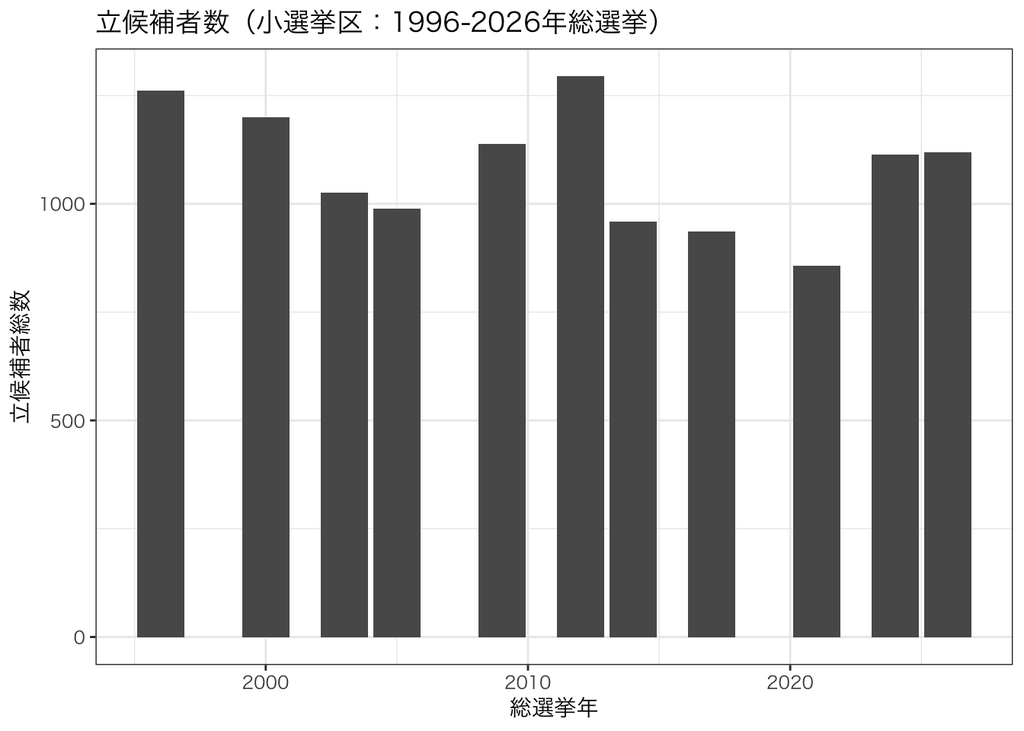

```r
df %>%
  ggplot() +
  geom_bar(aes(x = year)) +
  labs(x = "総選挙年", y = "立候補者総数") +
  ggtitle("立候補者数（小選挙区：1996-2026年総選挙）") +
  theme_bw(base_family = "HiraKakuProN-W3") # 文字化け対策
```

- x 軸の「総選挙年」の間隔が不自然  
  その理由：`year` の `class` が `numeric` だから
- `str()` 関数を使って `year` の `class` を確認

```r
str(df$year)
```

```
 num [1:11892] 1996 1996 1996 1996 1996 ...
```

- `year` の `class` は `numeric`（数値）  
  → `R` は `year` を連続変数だと認識する  
  → 総選挙は 4 年以内に実施されるが、必ずしも「4年ごと」に実施されるわけではない  
  → x 軸の間隔がバラバラ

**解決策：**

- `year` の `class` を `numeric`（数値）から `factor` に変更する

```r
df$year <- factor(df$year)
```

- `year` の `class` を確認

```r
str(df$year)
```

```
 Factor w/ 11 levels "1996","2000",..: 1 1 1 1 1 1 1 1 1 1 ...
```

- `year` の `class` は `factor` に変更された

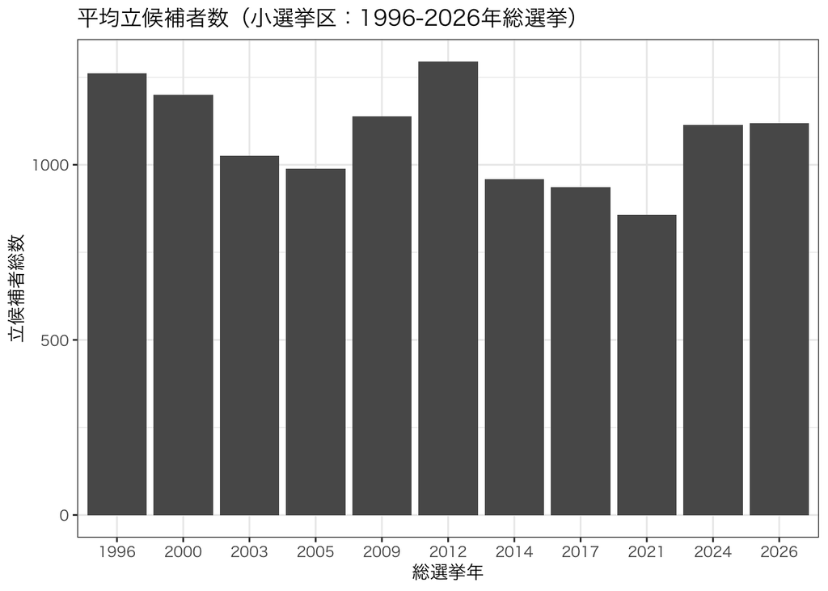

```r
df %>%
  ggplot() +
  geom_bar(aes(x = year)) +
  labs(x = "総選挙年",
       y = "立候補者総数") +
  ggtitle("平均立候補者数（小選挙区：1996-2026年総選挙）") +
  theme_bw(base_family = "HiraKakuProN-W3") # 文字化け対策
```

- 図を作成したら、適切な名前（例えば `bar_plot1` など）のオブジェクトとして格納できる
- 図の保存方法の詳細は`「5 グラフの保存方法」`を参照

```r
bar_plot1 <- df %>%
  ggplot() +
  geom_bar(aes(x = year)) +
  labs(x = "総選挙年",
       y = "立候補者総数")+
  ggtitle("立候補者数（小選挙区：1996-2026年総選挙）") +
  theme_bw(base_family = "HiraKakuProN-W3") # 文字化け対策
```

- 格納された図を出力する場合はオブジェクト名のみ (`bar_plot1`) 入力すればよい

このグラフからわかること ・総選挙における立候補者総数は、1996年以降（2009年と2012年を除き）2021年までは減少傾向だったが、2024年と2026年に増加傾向にある

## 3.2 シンプルな棒グラフ(2)

- 1996年から2026年までの総選挙における立候補者の**「小選挙区ごとの立候補者数の平均」**を総選挙ごとに棒グラフで表示してみる
- 必要なデータは次の 2 つ：
1. 総選挙年 (1996, 2000, 2003,…, 2026)
2. 総選挙年・小選挙区ごとの立候補者数の平均
- データは前節で作成した `df` を使う
- 「総選挙年」を横軸、「立候補者数の平均」を縦軸に指定
- `df` の中には「総選挙年」を表す変数 `year` はある
- しかし「立候補者数の平均」を表す変数がない  
  → `group_by()` 関数を使って「総選挙・小選挙区ごとの立候補者数の平均」を計算し、`ave_nocand1` として格納する

```r
df1 <- df %>%
  group_by(year, ku, kun) %>%
  summarise(ave_nocand1 = mean(nocand,
    na.rm = TRUE))

df1
```

```
# A tibble: 3,251 × 4
# Groups:   year, ku [517]
   year  ku      kun ave_nocand1
   <fct> <chr> <dbl>       <dbl>
 1 1996  aichi     1           7
 2 1996  aichi     2           8
 3 1996  aichi     3           7
 4 1996  aichi     4           6
 5 1996  aichi     5           7
 6 1996  aichi     6           8
 7 1996  aichi     7           7
 8 1996  aichi     8           5
 9 1996  aichi     9           7
10 1996  aichi    10           7
# ℹ 3,241 more rows
```

- ここで知りたいのは総選挙ごとの各小選挙区における立候補者数の平均なので、`ave_nocand1` を使って総選挙ごとの平均を求め 、`ave_nocand2` として格納する

```r
df1 <- df1 %>%
  group_by(year) %>%
  summarise(ave_nocand2 = mean(ave_nocand1,
    na.rm = TRUE))

df1
```

```
# A tibble: 11 × 2
   year  ave_nocand2
   <fct>       <dbl>
 1 1996         4.20
 2 2000         4.00
 3 2003         3.42
 4 2005         3.30
 5 2009         3.81
 6 2012         4.31
 7 2014         3.28
 8 2017         3.24
 9 2021         2.99
10 2024         3.85
11 2026         3.87
```

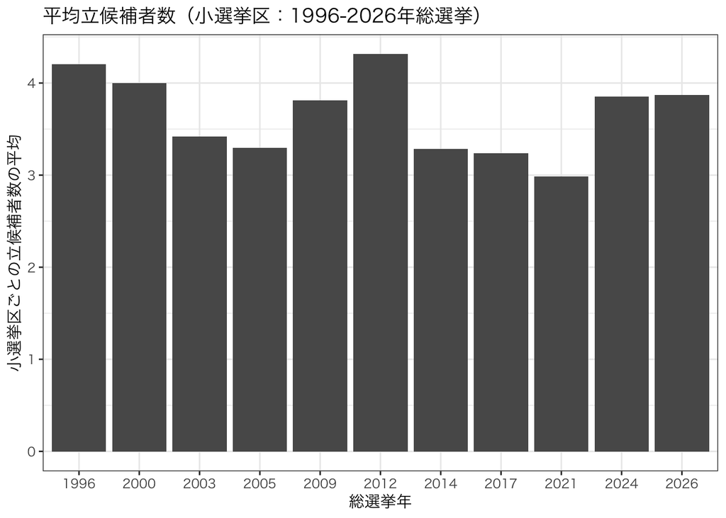

```r
df1 %>%
  ggplot() +
  geom_bar(aes(x = year,
               y = ave_nocand2),
           stat = "identity") +
  labs(x = "総選挙年", y = "小選挙区ごとの立候補者数の平均") +
  ggtitle("平均立候補者数（小選挙区：1996-2026年総選挙）") +
  theme_bw(base_family = "HiraKakuProN-W3") # 文字化け対策
```

このグラフからわかること ・総選挙における立候補者総数は、2021年までは減少傾向にあったが、2024年と2026年には増加傾向にある

## 3.3 日本語表記の問題

- 1996年から2026年までの総選挙における**現職、新人、元職（以前、当選したが全回の選挙で落選した人）別の棒グラフ**を描いてみよう
- 必要なデータは次の 2 つ：
1. 現職・新人・元職の分類を表す変数 (`status`)
2. 現職・新人・元職それぞれの立候補者数 (`N`)
- データは前節で作成した `df` を使う
- `status = 0` は新人、`status = 1` は現職、 `status = 2` は元職
- まず、`table()` 関数を使って、出馬した立候補者数を確かめる

```r
table(df$status)
```

```
   0    1    2
6808 4315  769
```

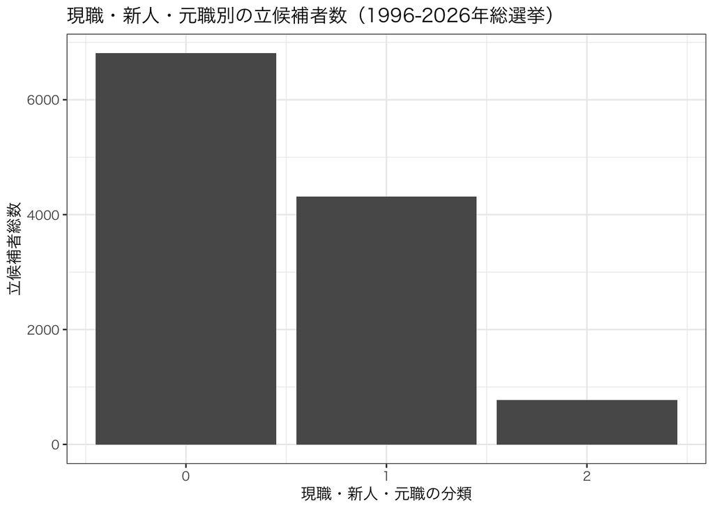

```r
df %>%
  ggplot() +
  geom_bar(aes(x = status)) +
  labs(x = "現職・新人・元職の分類", y = "立候補者総数") +
  ggtitle("現職・新人・元職別の立候補者数（1996-2026年総選挙）") +
  theme_bw(base_family = "HiraKakuProN-W3") # 文字化け対策
```

- 棒グラフには「新人・現職・元職の分類」の分類が「0, 1, 2」と表示されている
- これを「新人・現職・元職」という日本語の表記に修正する必要がある
- `case_when()` 関数を使って `df` の変数 `status` を日本語にリコーディングする
- `status_J` という新たな変数として追加し、データフレーム `df2` に格納する

```r
df2 <- df %>%
   mutate(status_J = case_when(status == "0" ~ "新人",
                               status == "1" ~ "現職",
                               TRUE  ~ "元職"))
```

- `x = status` の代わりに `x = status_J` と指定すれば良い

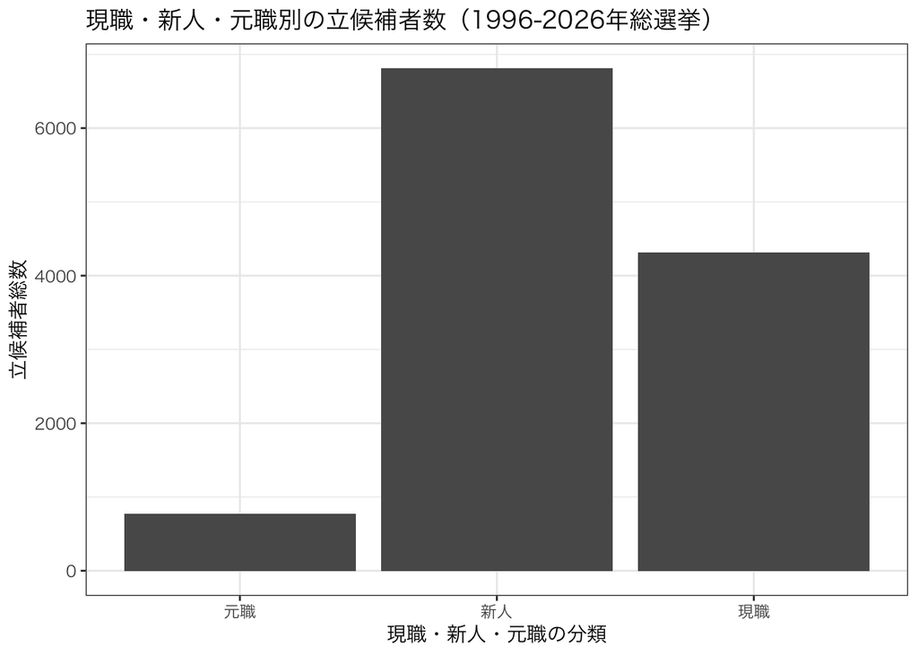

```r
df2 %>%
  ggplot() +
  geom_bar(aes(x = status_J)) +
  labs(x = "現職・新人・元職の分類",
       y = "立候補者総数") +
  ggtitle("現職・新人・元職別の立候補者数（1996-2026年総選挙）") +
  theme_bw(base_family = "HiraKakuProN-W3") # 文字化け対策
```

グラフ内の文字化け対策  
**Windows ユーザーの場合「文字化け対策」**として次のコマンドを打つこと  
`theme_bw(base_family = "HiraKakuProN-W3")`

**Mac ユーザーの場合「文字化け対策」**として次のコマンドを打つこと  
`theme_bw(base_family = "HiraKakuProN-W3")`

## 3.4 棒グラフの「棒」の順番を変更する

### 3.4.1 `factor()` 関数

- 前節で作成した棒グラフでは左から「元職・新人・現職」という順番
- この順番を「現職・新人・元職」に並べ替えたいとする
- **変数 `status_J` を `factor` 化する**  
  → 順番を並べ替える
- `df2` を `ggplot()` 関数に渡す前に `mutate()` 関数 を入れ、そこで `status_J` 変数を `factor` 化する  
  → 順番を指定する：`levels = c("現職", "新人", "元職")`

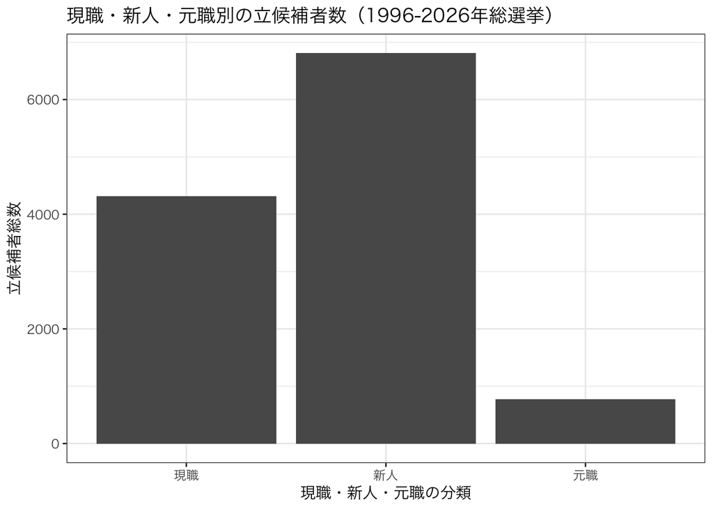

```r
df2 %>%
   mutate(status_J = factor(status_J,
                            levels = c("現職", "新人", "元職"))) %>%
   ggplot() +
   geom_bar(aes(x = status_J)) +
   labs(x = "現職・新人・元職の分類",
        y = "立候補者総数") +
  ggtitle("現職・新人・元職別の立候補者数（1996-2026年総選挙）") +
  theme_bw(base_family = "HiraKakuProN-W3") # 文字化け対策
```

- 想定通りの順番になっている

### 3.4.2 `fct_inorder()` 関数

- この関数は `forcats` パッケージに含まれている
- `forcats` パッケージは `tidyverse` パッケージに含まれている
- `tidyverse` パッケージを読み込んだら別途読み込む必要はない
- `fct_inorder()` 関数は `()` 内の変数を `factor` 化し
- 各要素が登場する順番に表示してくれる関数
- `df2` の `status_J` の値（=要素）がどのような順番で登場しているか確認してみる

```r
head(df2$status_J)
```

```
[1] "新人" "新人" "新人" "新人" "現職" "元職"
```

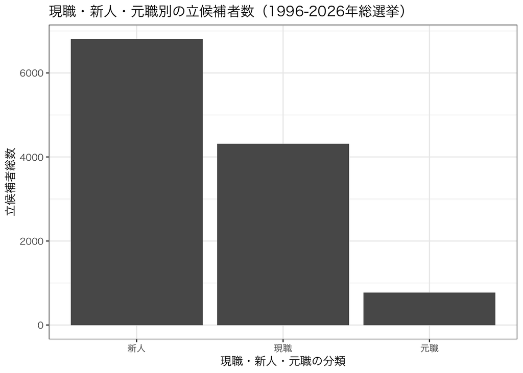

```r
df2 %>%
   mutate(status_J = fct_inorder(status_J)) %>%
   ggplot() +
   geom_bar(aes(x = status_J)) +
   labs(x = "現職・新人・元職の分類", y = "立候補者総数") +
  ggtitle("現職・新人・元職別の立候補者数（1996-2026年総選挙）") +
  theme_bw(base_family = "HiraKakuProN-W3") # 文字化け対策
```

## 3.5 次元を追加する

### 3.5.1 2026年総選挙での政党別立候補者数

```r
df26 <- df %>%
  filter(year == 2026)
```

```r
table(df26$seito)
```

```
みらい れいわ   中道   保守   共産   参政   国民   減ゆ   無所   社民   維新
     6     18    202      6    158    182    102     13     41      8     87
  自民   諸派
   285     11
```

- 13 の政党を表す変数である `seito` を `factor` 化する
- 棒グラフを表示する順番を指定する
- その前に、各政党ごとの候補者数を確かめる
- 頻度の多い順（降順）に並べ替えて表示させる

```r
sort(table(df26$seito),
  decreasing = TRUE)
```

```
  自民   中道   参政   共産   国民   維新   無所 れいわ   減ゆ   諸派   社民
   285    202    182    158    102     87     41     18     13     11      8
みらい   保守
     6      6
```

**棒を表示する順番を指定する方法**  
・例えば、政党 (`seito`) を自民、立憲、共産という順番で表示したけければ、変数をファクター化する際に順番を指定する  
`mutate(seito = factor(seito,`  
`levels = c("自民", "立憲", "共産")))`

```r
df26 <- df26 %>%
   drop_na(seito) %>%
   mutate(seito = factor(seito,
                         levels = c("自民",
                                    "中道",
                                    "参政",
                                    "共産",
                                    "国民",
                                    "維新",
                                    "無所",
                                    "れいわ",
                                    "減ゆ",
                                    "諸派",
                                    "社民",
                                    "保守",
                                    "みらい")))
```

### 3.5.2 立候補者数 `N` を計算（性別・政党別・当落別）

- `df26` を使って性別と政党別に立候補者数 `N` を計算  
  → 計算結果に `res_1` と名前を付ける

```r
 res_1 <- df26 %>%
   group_by(seito, gender, wl) %>%  # 政党別、性別、当落別に立候補者数 N を計算
   summarise(N = n())
```

```r
DT::datatable(res_1)
```

|  | seito | gender | wl | N |
| --- | --- | --- | --- | --- |
| 1 | 自民 | female | 0 | 2 |
| 2 | 自民 | female | 1 | 24 |
| 3 | 自民 | female | 2 | 3 |
| 4 | 自民 | male | 0 | 9 |
| 5 | 自民 | male | 1 | 224 |
| 6 | 自民 | male | 2 | 23 |
| 7 | 中道 | female | 0 | 38 |
| 8 | 中道 | female | 2 | 4 |
| 9 | 中道 | male | 0 | 144 |
| 10 | 中道 | male | 1 | 7 |

[output cut: 35 more lines]

- 棒グラフで可視化してみる

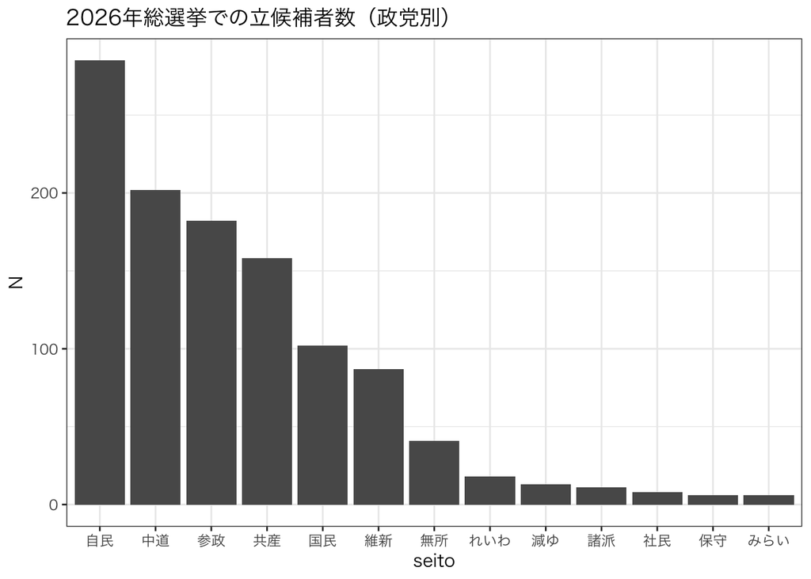

```r
res_1 %>%
   ggplot() +
   geom_bar(aes(x = seito,
                y = N),
            stat = "identity") +
  ggtitle("2026年総選挙での立候補者数（政党別）") +
  theme_bw(base_family = "HiraKakuProN-W3") # 文字化け対策
```

- この棒グラフが持つ情報は 2 つ
- `x` で指定した所属政党 `seito`
- `y` で指定した立候補者数 `N`

### 3.5.2 次元を追加する

##### `fill = gender`

- 上で作成した図に、もう一つの次元として「候補者の性別」`gender` を加える
- 次元を追加するときには `aes()` 内に引数を追加する
- 「棒」は点・線・面のうち、面に該当
- 面には次の要素がある：  
  ・面の色（`fill`）  
  ・枠線の色（`color`）  
  ・枠線のタイプ（`linetype`）  
  ・透明度（`alpha`）など
- もう一つの次元を追加するのであれば、識別する定番の方法は色
- 棒グラフの場合、「面の色」と「枠線の色」をそれぞれ指定可能
- ここでは面の色（`fill`）にマッピングする
- `aes()`内に `fill = gender` を追加する

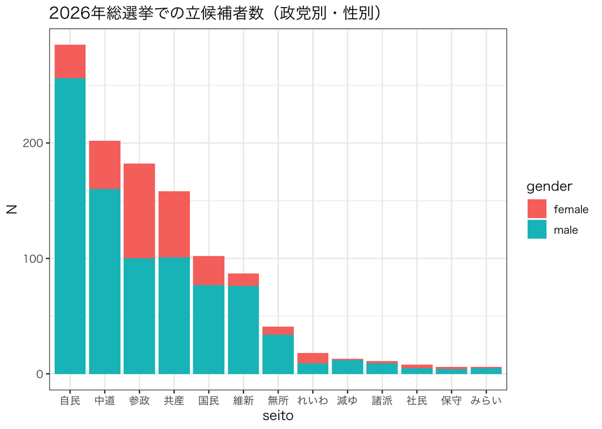

```r
res_1 %>%
  ggplot() +
  geom_bar(aes(x = seito,
               y = N,
               fill = gender),
           stat = "identity") +
  ggtitle("2026年総選挙での立候補者数（政党別・性別）") +
  theme_bw(base_family = "HiraKakuProN-W3") # 文字化け対策
```

### 3.5.3 棒を左右にずらす

##### `position = "dodge"`

- 上の図は政党ごとに男性と女性がどのような割合で立候補しているか確認できるが、少々見にくい
- 政党ごとに棒を男女別に並べてずらして (`dodge`) みる
- `geom_bar()` 内に `position = "dodge"` を指定する
- `aes()` の「中」でなく、「外」に指定すること

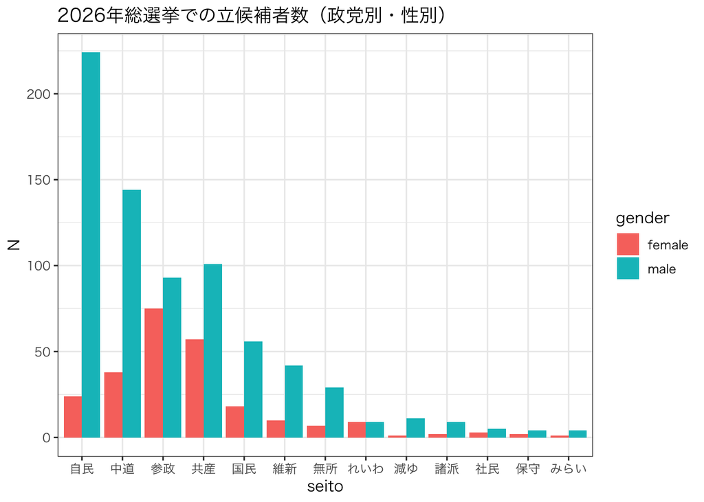

```r
res_1 %>%
  ggplot() +
  geom_bar(aes(x = seito,
               y = N,
               fill = gender),
           stat = "identity",
           position = "dodge") + # position = "dodge" を aes() の「外」に指定
  ggtitle("2026年総選挙での立候補者数（政党別・性別）") +
  theme_bw(base_family = "HiraKakuProN-W3") # 文字化け対策
```

### 3.5.4 凡例の位置変更

##### `theme(legend.position = "bottom")`

- 凡例の位置を変更してみる
- グラフ全体の見た目などを細かく調整するレイヤーは `theme()`
- この `theme()` 内に `legend.position = "bottom"` を指定  
  → 凡例が図の下段へ移動する
- デフォルトは `"right"`（`"top", "left", "none"` が指定可能）

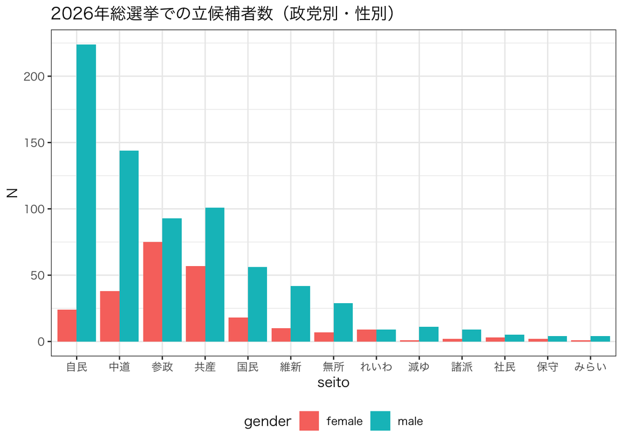

```r
res_1 %>%
  ggplot() +
  geom_bar(aes(x = seito,
               y = N,
               fill = gender),
           stat = "identity",
           position = "dodge") +
  ggtitle("2026年総選挙での立候補者数（政党別・性別）") +
  theme_bw(base_family = "HiraKakuProN-W3") + # 文字化け対策
  theme(legend.position = "bottom")
```

## 3.6 ファセット分割

- ファセット（`facet`）分割は、色を使った分類を避けたい時に効果的
- 特に白黒印刷の場合、識別可能な色は白・グレー・黒の 3 つくらい
- しかし、色の種類は増えると、白黒印刷では識別するのが難しい
- プロットの面（=ファセット）を分割することで色の増加が抑制できる
- `facet_wrap(~ 分割の基準となる変数名)` のレイヤーを加える
- 所属政党ごとの男女別立候補者数の棒グラフを作成する
- それぞれの棒グラフは政党ごとに独立したファセットを持つ

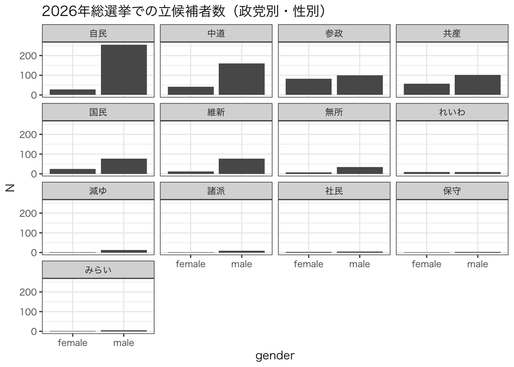

```r
res_1 %>%
  ggplot() +
  geom_bar(aes(x = gender,
               y = N),
           stat = "identity") +
  ggtitle("2026年総選挙での立候補者数（政党別・性別）") +
  theme_bw(base_family = "HiraKakuProN-W3") + # 文字化け対策
  facet_wrap(~ seito) # 分割の基準は seito と指定
```

- 男女別にファセットと作って政党ごとに比較もできる
- それぞれの棒グラフは性別ごとに独立したファセットを持つ

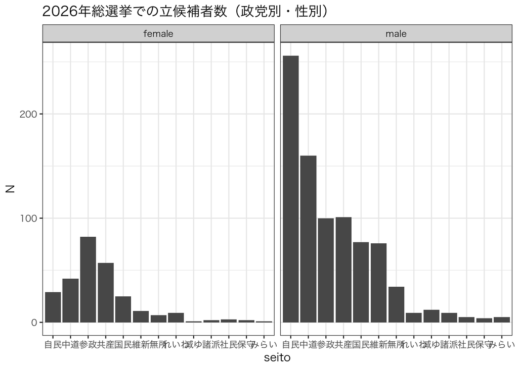

```r
res_1 %>%
  ggplot() +
  geom_bar(aes(x = seito,
               y = N),
           stat = "identity") +
  ggtitle("2026年総選挙での立候補者数（政党別・性別）") +
  theme_bw(base_family = "HiraKakuProN-W3") + # 文字化け対策
  facet_wrap(~ gender) # 分割の基準は seito と指定
```

## 3.7 ラベルを見やすく修正

##### `theme(axis.text.x = element_text(angle = XX, vjust = X, hjust = X)`

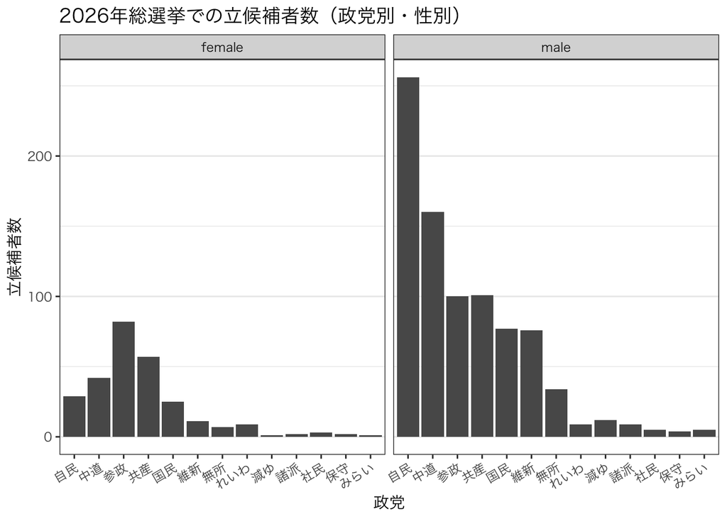

```r
res_1 %>%
  ggplot() +
  geom_bar(aes(x = seito,
               y = N),
           stat = "identity") +
  facet_wrap(~ gender) + # 分割の基準は seito と指定
  labs(x = "政党", y = "立候補者数") + # ラベル修正
  ggtitle("2026年総選挙での立候補者数（政党別・性別）") +
  theme_minimal() + # テーマを変えてみよう
  theme_bw(base_family = "HiraKakuProN-W3") + # 文字化け対策
  theme(axis.text.x        = element_text(angle = 30, vjust = 1, hjust = 1),
        panel.grid.major.x = element_blank())
```

## 3.8 ファセットに新たなレイヤーを追加

- `aes()` の内側に `fill = 変数` と指定することで、新たなレイヤーを色別して追加できる
- `elec_result` という変数を作ってから、`ggplot()` に渡す

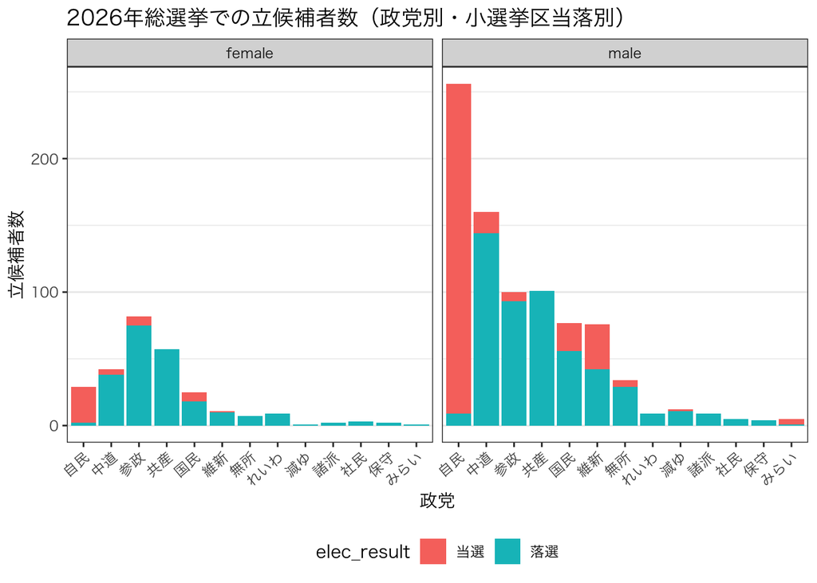

```r
res_1 %>%
  mutate(elec_result = if_else(wl == "0", "落選", "当選")) %>%
  ggplot() +
  geom_bar(aes(x = seito,
               y = N,
               fill = elec_result),                 # 新たなレイヤー elec_result の追加
           stat = "identity") +
  facet_wrap(~ gender) +                       # 分割の基準は gender と指定
  labs(x = "政党", y = "立候補者数") +            # ラベル修正
  ggtitle("2026年総選挙での立候補者数（政党別・小選挙区当落別）") +
  theme_minimal() +                            # テーマを変えてみよう
  theme_bw(base_family = "HiraKakuProN-W3") +  # 文字化け対策
  theme(axis.text.x = element_text(angle = 40, # 40度回転
                                   vjust = 1,
                                   hjust = 1),
        panel.grid.major.x = element_blank())  + # 縦線グリッドを削除
   theme(legend.position = "bottom")             # レジェンドの位置指定
```

## 3.9 `x` 軸と `y` 軸を入れ替える

#### `x` 軸と `y` 軸を入れ替える方法

- `x` 軸のラベルが長くて左右オーバーラップする場合  
  → `x` 軸と `y` 軸を入れ替える

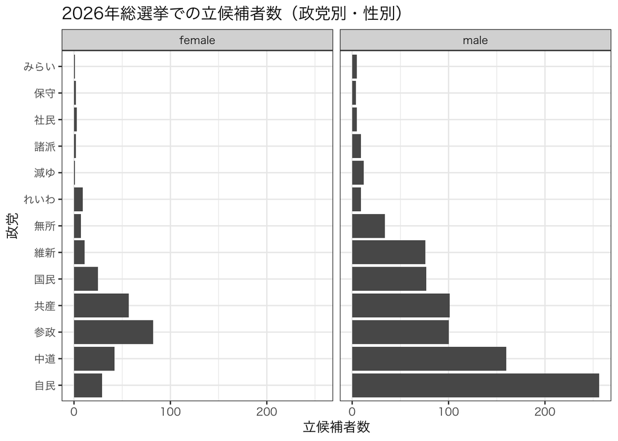

```r
res_1 %>%
  ggplot() +
  geom_bar(aes(x = N,
               y = seito),
           stat = "identity") +
  facet_wrap(~ gender) + # 分割の基準は gender と指定
  labs(x = "立候補者数", y = "政党") + # ラベル修正
  ggtitle("2026年総選挙での立候補者数（政党別・性別）") +
  theme_minimal() + # テーマを変えてみよう
  theme_bw(base_family = "HiraKakuProN-W3")
```

#### `coord_flip()` を加える方法

- `coord_flip()` を加えても、同様の結果が得られる

```r
res_1 %>%
  ggplot() +
  geom_bar(aes(x = seito,
               y = N),
           stat = "identity") +
  facet_wrap(~ gender) + # 分割の基準は gender と指定
  labs(x = "立候補者数", y = "政党") + # ラベル修正
  theme_minimal() + # テーマを変えてみよう
  theme_bw(base_family = "HiraKakuProN-W3") +
  coord_flip()
```

[output not shown]

# 4. 棒に数値を表示させる

##### `geom_text(aes(label = 表示させたい内容))` を指定する

## 4.1 シンプルな棒グラフの場合

- 例えば、次の棒グラフの棒それぞれに数値を表示させたいとする

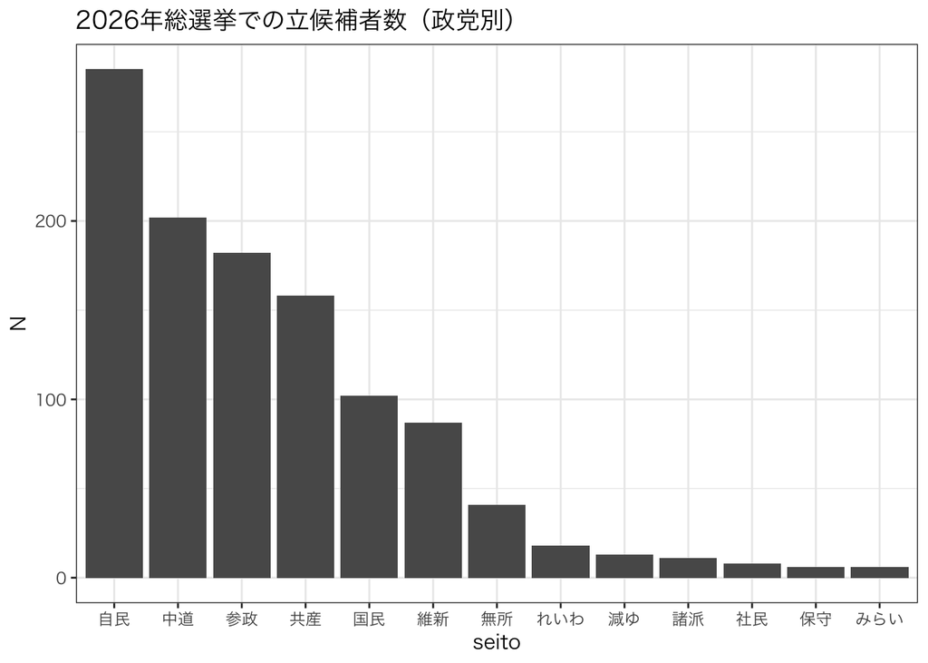

res_1を作った課程を確認する

```r
df <- read_csv("data/hr96-26.csv", # 総選挙データの読み込み
               na = ".")
```

```r
df26 <- df %>%
  filter(year == 2026) %>% # 2026年総選挙データだけに絞り df24 と名前を付ける
  drop_na(seito) %>%　　　 # seito の欠損値を除外する

  mutate(seito = factor(seito,           # seito をファクター化し政党名の表示順序を指定
                         levels = c("自民",
                                    "中道",
                                    "参政",
                                    "共産",
                                    "国民",
                                    "維新",
                                    "無所",
                                    "れいわ",
                                    "減ゆ",
                                    "諸派",
                                    "社民",
                                    "保守",
                                    "みらい")))
```

```r
res_1 <- df26 %>%  # 政党別、性別、当落別に立候補者数 N を計算し、res_1と名前と付ける
   group_by(seito, gender, wl) %>%
   summarise(N = n())
```

- `res_1` の内容を表示させる

```r
DT::datatable(res_1)
```

|  | seito | gender | wl | N |
| --- | --- | --- | --- | --- |
| 1 | 自民 | female | 0 | 2 |
| 2 | 自民 | female | 1 | 24 |
| 3 | 自民 | female | 2 | 3 |
| 4 | 自民 | male | 0 | 9 |
| 5 | 自民 | male | 1 | 224 |
| 6 | 自民 | male | 2 | 23 |
| 7 | 中道 | female | 0 | 38 |
| 8 | 中道 | female | 2 | 4 |
| 9 | 中道 | male | 0 | 144 |
| 10 | 中道 | male | 1 | 7 |

[output cut: 35 more lines]

```r
res_2 <- res_1 %>%
  group_by(seito) %>%
  summarize(party_cand = sum(N))　# 性別と政党ごとに N を合計し total と名前と付け res_2 に格納する
```

- `res_2` の内容を表示させる

```r
DT::datatable(res_2)
```

|  | seito | party_cand |
| --- | --- | --- |
| 1 | 自民 | 285 |
| 2 | 中道 | 202 |
| 3 | 参政 | 182 |
| 4 | 共産 | 158 |
| 5 | 国民 | 102 |
| 6 | 維新 | 87 |
| 7 | 無所 | 41 |
| 8 | れいわ | 18 |
| 9 | 減ゆ | 13 |
| 10 | 諸派 | 11 |

[output cut: 3 more lines]

- `geom_text(aes(label = party_cand)` を使って数値を表示させる

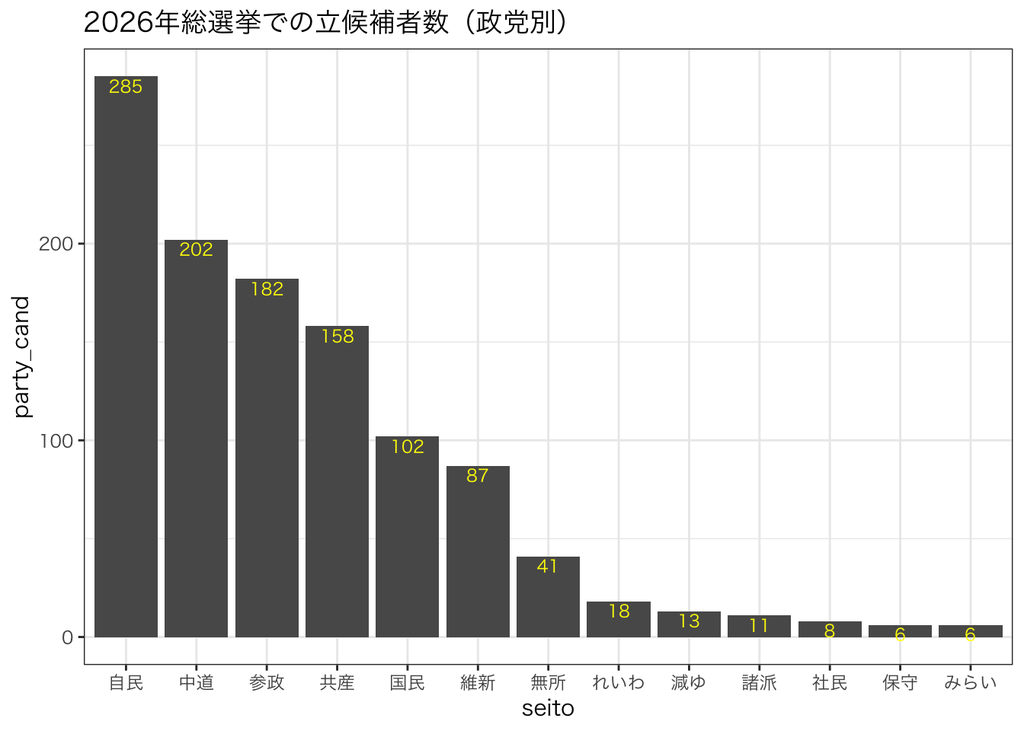

```r
res_2 %>%
  ggplot(aes(x = seito,
               y = party_cand)) +
  geom_bar(aes(),
           stat = "identity",
           position = position_dodge(width = 0.9)) +
  geom_text(aes(label = party_cand),
            vjust = 1.2,
            colour = "yellow",
            position = position_dodge(width = 0.9),
            size = 3) +
  theme_bw(base_family = "HiraKakuProN-W3") +
  ggtitle("2026年総選挙での立候補者数（政党別）") +
  theme(legend.position = "bottom")
```

## 4.2 ずらした棒グラフの場合

- 例えば、次の棒グラフの棒それぞれに数値を表示させたいとする

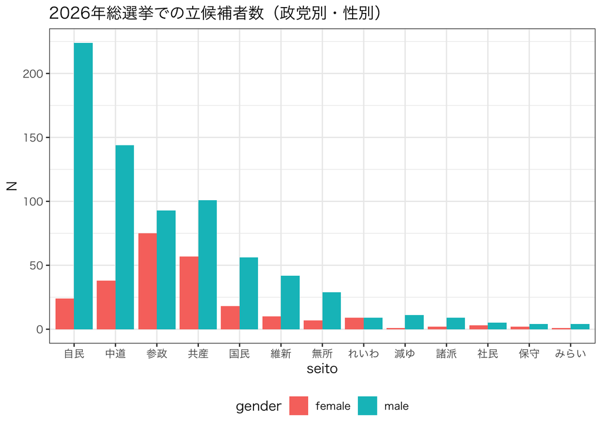

```r
DT::datatable(res_1)
```

|  | seito | gender | wl | N |
| --- | --- | --- | --- | --- |
| 1 | 自民 | female | 0 | 2 |
| 2 | 自民 | female | 1 | 24 |
| 3 | 自民 | female | 2 | 3 |
| 4 | 自民 | male | 0 | 9 |
| 5 | 自民 | male | 1 | 224 |
| 6 | 自民 | male | 2 | 23 |
| 7 | 中道 | female | 0 | 38 |
| 8 | 中道 | female | 2 | 4 |
| 9 | 中道 | male | 0 | 144 |
| 10 | 中道 | male | 1 | 7 |

[output cut: 35 more lines]

- `res_1` を使って 13 の**「政党それぞれの男女別の立候補者総数」= total** を計算  
  → 結果を `res_3` と名付ける

```r
res_3 <- res_1 %>%
  group_by(seito, gender) %>%
  summarize(total = sum(N))　# 性別と政党ごとに N を合計し total と名前と付け res_2 に格納する
```

- `res_3` の内容を表示させる

```r
DT::datatable(res_3)
```

|  | seito | gender | total |
| --- | --- | --- | --- |
| 1 | 自民 | female | 29 |
| 2 | 自民 | male | 256 |
| 3 | 中道 | female | 42 |
| 4 | 中道 | male | 160 |
| 5 | 参政 | female | 82 |
| 6 | 参政 | male | 100 |
| 7 | 共産 | female | 57 |
| 8 | 共産 | male | 101 |
| 9 | 国民 | female | 25 |
| 10 | 国民 | male | 77 |

[output cut: 16 more lines]

- `geom_text(aes(label = total)` を使って数値を表示させる

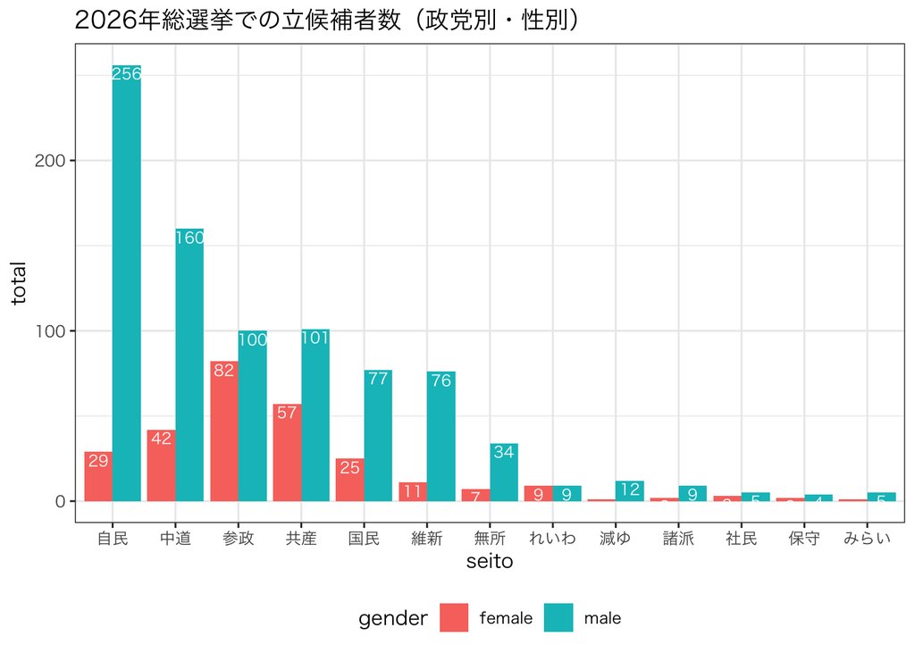

```r
res_3 %>%
  ggplot(aes(x = seito,
               y = total,
               fill = gender)) +
  geom_bar(aes(),
           stat = "identity",
           position = position_dodge(width = 0.9)) +
  geom_text(aes(label = total),
            vjust = 1.2,
            colour = "white",
            position = position_dodge(width = 0.9),
            size = 3) +
  theme_bw(base_family = "HiraKakuProN-W3") +
  ggtitle("2026年総選挙での立候補者数（政党別・性別）") +
  theme(legend.position = "bottom")
```

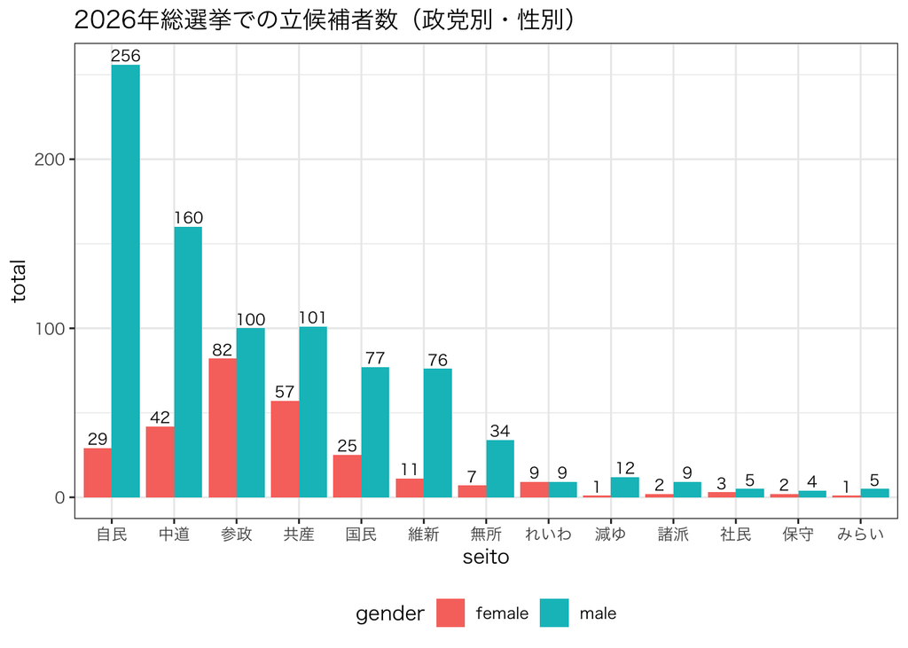

```r
res_3 %>%
  ggplot(aes(x = seito,
             y = total,
             fill = gender)) +
  geom_bar(stat = "identity",
    position = position_dodge(width = 0.9)) +
  geom_text(aes(label = total),
    colour = "black",
    position = position_dodge(width = 0.9),
    vjust = -0.3,     　　　　　　　　　　　# ← 数値を棒グラフの上に表示
    size = 3) +
  theme_bw(base_family = "HiraKakuProN-W3") +
  ggtitle("2026年総選挙での立候補者数（政党別・性別）") +
  theme(legend.position = "bottom")
```

## 4.3 重ねた棒グラフの場合

#### `position = "stack"` と指定

- 例えば、次の棒グラフの棒それぞれに数値を表示させたいとする

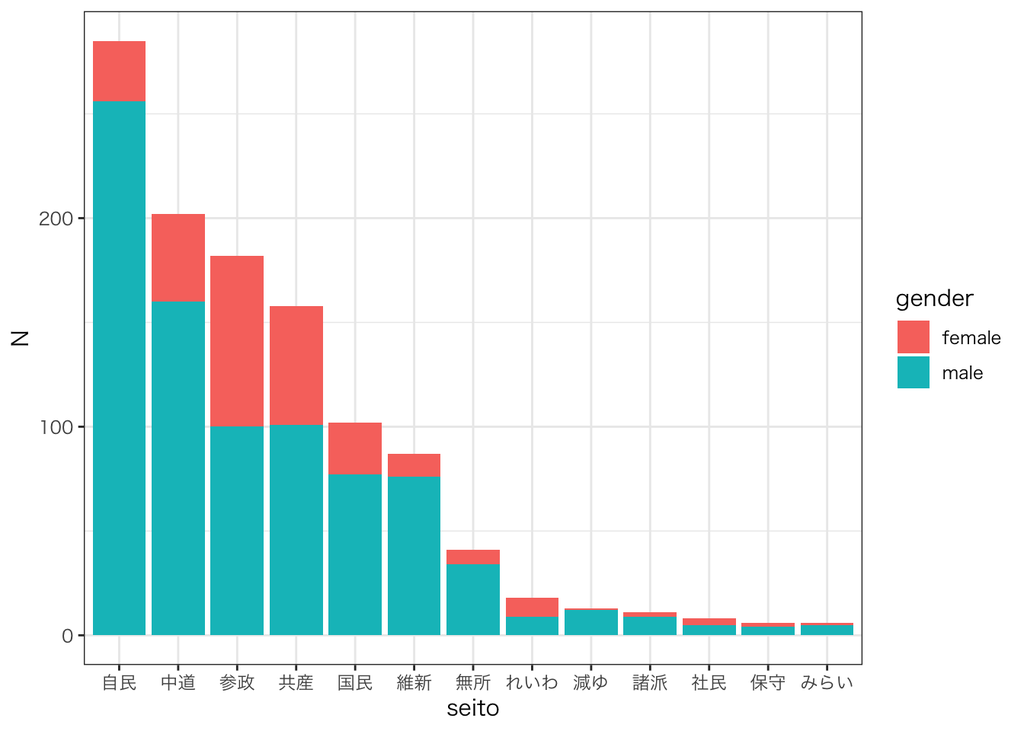

```r
res_4 <- res_1 %>%
  group_by(seito, gender) %>%
  summarize(total = sum(N))
```

- `res_4` の内容を表示させる

```r
DT::datatable(res_4)
```

|  | seito | gender | total |
| --- | --- | --- | --- |
| 1 | 自民 | female | 29 |
| 2 | 自民 | male | 256 |
| 3 | 中道 | female | 42 |
| 4 | 中道 | male | 160 |
| 5 | 参政 | female | 82 |
| 6 | 参政 | male | 100 |
| 7 | 共産 | female | 57 |
| 8 | 共産 | male | 101 |
| 9 | 国民 | female | 25 |
| 10 | 国民 | male | 77 |

[output cut: 16 more lines]

- `geom_text(aes(label = total)` を使って数値を表示させる

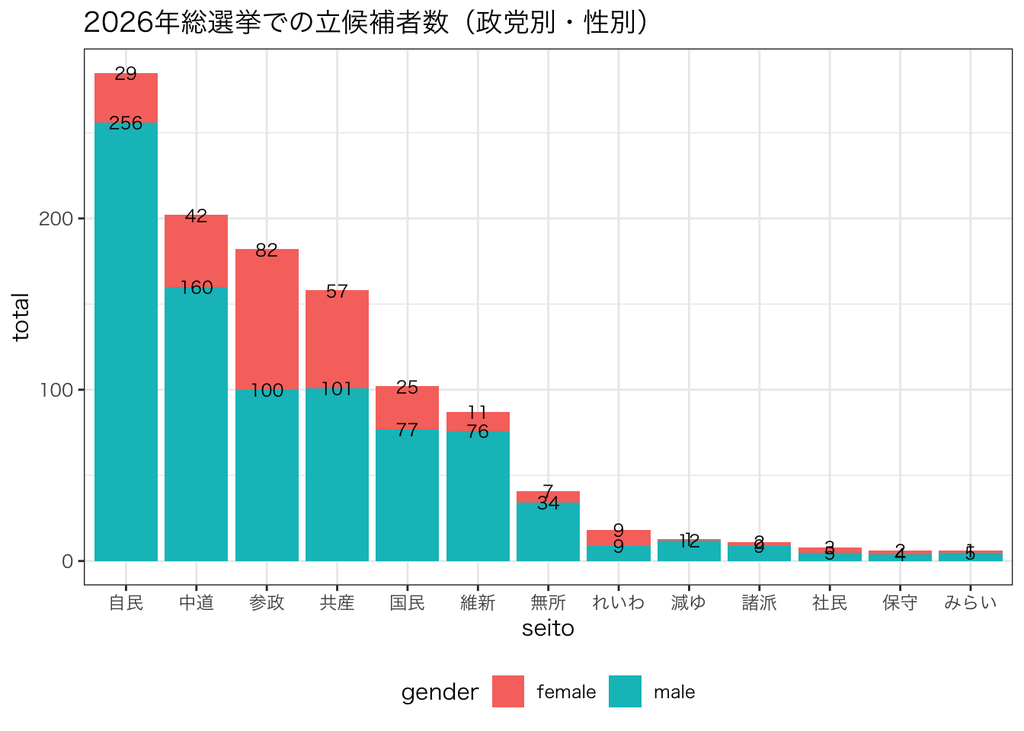

```r
res_4 %>%
  ggplot(aes(x = seito,
               y = total,
               fill = gender)) +
  geom_bar(aes(),
           stat = "identity",
           position = "stack") +  # position = "stack" に変更
  geom_text(aes(label = total),
            colour = "black",
            position = "stack",   # position = "stack" に変更
            size = 3) +
  theme_bw(base_family = "HiraKakuProN-W3") +
  ggtitle("2026年総選挙での立候補者数（政党別・性別）") +
  theme(legend.position = "bottom")
```

- これだと数値がうまく表示できない  
  → 数値を表示したければ、ずらした棒グラフを使うのがよい

# 5. グラフの保存方法

- 作成した図をファイルとして保存する方法は 2 つある

| 画像のフォーマット | 拡張子 | ファイルサイズ | 画質 |
| --- | --- | --- | --- |
| ベクトル画像 | `.pdf(推奨) .svg` | 大きい | 拡大しても綺麗 |
| ビットマップ画像 | `.png(推奨) .bmp .jpg .jpeg` | 小さい | そこそこ綺麗 |

##### Step 1:

- 作成した図にオブジェクト名を付ける（ここでは `bar_plot1` と付けた）
- `RProject` フォルダ内に図を保存するためのフォルダ `fig` を作る

##### Step 2:

- 次のコマンドをチャンクに入力して `knit` する

```r
library(ragg)
```

```r
ggsave(filename = "fig/plot1.png",     # 保存先とファイル名
       plot     = bar_plot1,         　 # 保存する図のオブジェクト名
       width    = 6,                  　# 図の幅 (インチ)
       height   = 3,                  　# 図の高さ (インチ)
       dpi      = 400,                　# 解像度
       device   = ragg::agg_png)      　# 文字化け防止
```

# 6. Exercise

- **Q6.1**:  
  `「3.1 シンプルな棒グラフ(1)」`を参考にして、1996年から2026年総選挙で立候補した男性の候補者数を棒グラフで描きなさい
- **Q6.2**:  
  `「3.1 シンプルな棒グラフ(1)」`を参考にして、1996年から2026年総選挙で立候補した女性の候補者数を棒グラフで描きなさい
- **Q6.3**:  
  `「3.5.3 棒を左右にずらす」`を参考にして、1996年から2026年総選挙で立候補した男性と女性の候補者数を棒グラフで描きなさい
- **Q6.4（難）**:  
  `「3.8 ファセットに新たなレイヤーを追加」`を参考にして、2026年総選挙において政党ごとの現職・新人・元職の当選者数を棒グラフで描きなさい  
  ・その際、当選者（小選挙区当選者 + 復活当選者）と落選者を色分けして表示しなさい
- **Q6.5（難）**:  
  `「4.2 ずらした棒グラフの場合」`を参考にして、2026年総選挙における当選者数（小選挙区・比例復活当選）と落選者数を棒グラフで描きなさい  
  ・その際、当選者と落選者を色分けして表示し、それぞれの人数を棒グラフの内側（もしくはその付近）に表示させなさい

**参考文献**

[Tidy Animated Verbs](https://github.com/gadenbuie/tidyexplain?fbclid=IwAR3Zt0pQZa0IEvP-1gstatQ42VM5yJZvw2vUaFEqt_m2smUgtZpTqvuurLJ6z0)

[宋財泫 (Jaehyun Song)・矢内勇生 (statuki statanai)「私たちのR: ベストプラクティスの探究」](https://www.jaysong.net/RBook/)

[宋財泫「ミクロ政治データ分析実習（2022年度）」](https://www.jaysong.net/micro-book/)

[土井翔平（北海道大学公共政策大学院）「Rで計量政治学入門」](https://shohei-doi.github.io/quant_polisci/data-import.html)

[矢内勇生（高知工科大学）授業一覧](http://yukiyanai.github.io/teaching/)

浅野正彦, 矢内勇生.『Rによる計量政治学』オーム社、2018年

浅野正彦, 中村公亮.『初めてのRStudio』オーム社、2018年

Kieran Healy, DATA VISUALIZATION, Princeton, 2019

Kosuke Imai, Quantitative Social Science: An Introduction, Princeton University Press, 2017